# Name: *Iñaky Ordiales*

## Assignment 01

### March 2023

```python
import numpy as np
import matplotlib.pyplot as plt
from matplotlib import patches
import torch
import torch.nn as nn
import PIL
from typing import Tuple

from IPython.display import clear_output

from torchvision.datasets.mnist import MNIST
from torch.utils.data import Dataset, DataLoader
```

#### Extra settings and imports for my specific notebook

```python
from torchvision.transforms import ToTensor
import random
from tqdm.notebook import tqdm
import copy

# Making the plots inside notebook
%matplotlib inline

# Enabling gpu processing if possible (not my case)
device = torch.device('cuda' if torch.cuda.is_available() else 'cpu')
print("The processing will be done in: "+str(device))
```

```
The processing will be done in: cpu
```

# Assignment 1 Deep Learning 2023

### Task 1. Prepare the data for the training.

Implement the `calculate_bounding_box` function. Given a MNIST image it should output the bounding box of the digit as a tuple of 4 numbers [left, right, up, down] for the corresponding bounds. Rely on the fact that the background consists of only black pixels.

#### Calculating box implementation

The easiest way in which I could think of manually calculating the box, was to go through the pixels in a 2d array and save the position in which it has a value bigger than 0 (not black). For this to work I had to do it for times starting in different directions: up->down, down->up, left->right, right->left.

```python
def calculate_bounding_box(x: PIL.Image.Image) -> Tuple[float, float, float, float]:
    """
    Calculates the bounding box of a digit from the MNIST dataset.

    :param x: A 28x28 grayscale image from the MNIST dataset.
    :return: Tuple (left, right, up, down).
    """

    bounding_box = None

    ##### Write your code here #####

    x_ar = np.asarray(x)

    left = -1
    right = -1
    up = -1
    down = -1

    for j in range(28):
        for i in range(28):
            if(x_ar[i][27-j]!= 0):
                left = 27-j
                j = 28
                break

    for j in range(28):
        for i in range(28):
            if(x_ar[i][j] != 0):
                right = j
                j=28
                break

    for i in range (28):
        for j in range (28):
            if(x_ar[27-i][j] != 0):
                up = 27-i
                i=28
                break

    for i in range(28):
        for j in range(28):
            if(x_ar[i][j] != 0):
                down = i
                i=28
                break

    if left == -1:
        left = 0

    if right == -1:
        right = 27

    if up == -1:
        up = 0

    if down == -1:
        down = 27

    bounding_box = torch.tensor([left, right, up, down])

    ################################

    return bounding_box
```

Implement the `Digits` dataset class that wraps the MNIST class and augments it with the bounding box of each digit.

#### Implementation for Digits class

Here the solution is self explanatory, we create an atribute mnist that downloads from the MNIST dataset when the object gets initialized. And then we make that when accesing an element of the object it returns only the image tensor and the calculated bounding_box label as a flot tensor (this is such that loss function can do the correct datatype calculations).

```python
class Digits(Dataset):
    def __init__(self, root: str, train: bool = True, download: bool = True):
        super(Digits, self).__init__()

        # Construct your MNIST instance here
        self.mnist = MNIST(root=root, train=train, download=download)

    def __getitem__(self, idx: int) -> Tuple[torch.FloatTensor, torch.FloatTensor]:
        """
        Returns the datapoint at index = idx.

        :param idx: Index of the datapoint.
        :return: Image tensor, its bounding box.
        """

        ##### Write your code here #####

        img = ToTensor()(self.mnist[idx][0])
        bounding_box = calculate_bounding_box(self.mnist[idx][0])
        bounding_box = bounding_box.to(torch.float32)

        return img, bounding_box

        ################################

    def __len__(self) -> int:
        """
        Returns the length of the dataset. Equals the length of the MNIST dataset.

        :return: The total number of datapoints in the dataset.
        """

        ##### Write your code here #####

        return len(self.mnist)

        ################################
```

Construct the train and the test splits of the dataset. Leave 90% of the training set for training and the remaining 10% for the validation.

#### Splits of the dataset

We first create two datasets: one for training and one for testing. In order to spit the train set into 90% train and 10% validation we use a torch tool that randomly splits the data into a specify range. Once we have the datasets we make some dataloaders to use in the model training.

```python
##### Write your code here #####

train_set = Digits(root="data", train=True, download=True)

l = int(len(train_set)*0.9)

train_set, valid_set = torch.utils.data.random_split(train_set, [l, int(len(train_set)-l)])


test_set  = Digits(root="data", train=False, download=True)


train_loader = DataLoader(train_set, batch_size=32, shuffle=True,  num_workers=4)
valid_loader = DataLoader(valid_set, batch_size=32, shuffle=False, num_workers=4)
test_loader  = DataLoader(test_set,  batch_size=32, shuffle=False, num_workers=4)

################################
```

Visualize some datapoints.

#### For the points visualization

We make a function that recieves an image and the boundary label and plots it in red line.

```python
##### Write your code here #####

def visualizeData(img, boundary):
    bounds = boundary.to(torch.long)
    # left
    x1 = [bounds[0],bounds[0]]
    y1 = [bounds[2],bounds[3]]
    # right
    x2 = [bounds[1],bounds[1]]
    y2 = [bounds[2],bounds[3]]
    # up
    x3 = [bounds[0],bounds[1]]
    y3 = [bounds[2],bounds[2]]
    # down
    x4 = [bounds[0],bounds[1]]
    y4 = [bounds[3],bounds[3]]

    # plot bound box
    plt.plot(x1,y1, 'r', linewidth=4.0)
    plt.plot(x2,y2, 'r', linewidth=4.0)
    plt.plot(x3,y3, 'r', linewidth=4.0)
    plt.plot(x4,y4, 'r', linewidth=4.0)
    # format rest of the plot
    plt.suptitle(f"Label(L,R,U,D):    {bounds}")
    plt.imshow(img, cmap="gray")

################################
```

#### Plotting random data

we generate a random value from the train dataset and plot it with its boundaries

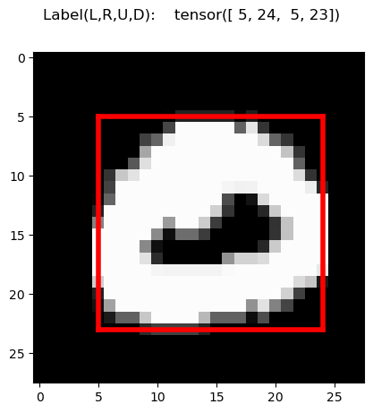

```python
r = random.randint(0, len(train_set))
visualizeData(train_set[r][0][0], train_set[r][1])
```

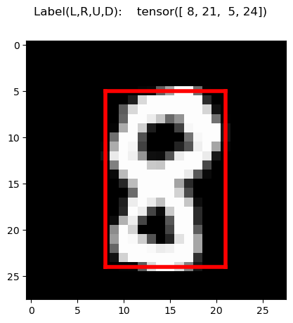

```python
r = random.randint(0, len(train_set))
visualizeData(train_set[r][0][0], train_set[r][1])
```

### Task 2. Train a linear model.

#### Linear model creation

For training the linear model we will create a class that initializes with the input and output size of the linear model and recieves a batch of 28x28 but converts it into 784. the atribute fc is itslef the linear neural network and every input passes through it and is then returned.

```python
##### Write your code here #####

class LinearModel(nn.Module):

    def __init__(self, input_dim, output_dim):
        super(LinearModel, self).__init__()
        self.fc = nn.Linear(input_dim, output_dim, bias=True)

    def forward(self, input):
        out = input.view(input.size(0), -1) # convert batch_size x 28 x 28 to batch_size x (28*28)
        out = self.fc(out) # Applies out = input * A + b. A, b are parameters of nn.Linear that we want to learn
        return out

################################
```

#### Functions for training and validating the model

For training the model we have two functions, the train epoch wich is where it gets really trained, and the train function where it calls the train epoch and validation function. The validation function just evaluated its dataset and returns the mean loss, boundaries accuracy and full box accuracy.

```python
def train_epoch(model, train_dataloader, optimizer, loss_fn):
    losses = []
    correct_val = 0
    correct_pred = 0
    # Go through the whole set of batches
    for digit, boundary in tqdm(train_dataloader):
        # enabling gpu porcessing if available
        digit = digit.to(device)
        boundary = boundary.to(device)
        # putting the input through the model and rezeroing gradients
        out = model(digit)
        optimizer.zero_grad()
        # getting the loss value for plotting it later
        loss = loss_fn(out, boundary)
        losses.append(loss.item())
        # backpropagation of values
        loss.backward()
        # optimization of the model with specified function
        optimizer.step()
        correct_val += (torch.round(out) == boundary).sum()
        correct_pred += torch.all((torch.round(out) == boundary), dim=1).sum()
    # calculating value and box accuracy
    point_accuracy = 100.0 * correct_val / (4*len(train_dataloader.dataset))
    border_accuracy = 100.0 * correct_pred / len(train_dataloader.dataset)
    # calculating mean loss value
    mean_loss = np.array(losses).mean()
    return mean_loss, point_accuracy, border_accuracy
```

Now for the evaluation of each epoch we have a function that uses the model to compute evaluation of accuracy and of loss but does not optimizes the model.

```python
def evaluate(model, eval_dataloader, loss_fn):
    losses = []
    correct_pred = 0
    correct_val = 0
    # disable gradient records
    with torch.no_grad():
        for digit, boundary in eval_dataloader:
            # enabling gpu porcessing if available
            digit = digit.to(device)
            boundary = boundary.to(device)
            # value predictions and rounding
            out = model(digit).round()
            # Compute loss
            loss = loss_fn(out.to(torch.float32), boundary.to(torch.float32))
            losses.append(loss.item())
            # Save metrics
            correct_val += (torch.round(out) == boundary).sum()
            correct_pred += torch.all((torch.round(out) == boundary), dim=1).sum()
    # calculating mean loss value
    mean_loss = np.array(losses).mean()
    # calculating point and box accuracy
    point_accuracy = 100.0 * correct_val / (4*len(eval_dataloader.dataset))
    border_accuracy = 100.0 * correct_pred / len(eval_dataloader.dataset)
    return mean_loss, point_accuracy, border_accuracy
```

Finally the general function for training will recieve a model (so we don't have to rewrite it), both train and validation loaders, the specific optimizer function for the model, the specific loss_function and the number of epochs to train the model for.

```python
def train(model, train_dataloader, val_dataloader, optimizer, loss_fn, n_epochs):
    train_losses     = []
    val_losses       = []
    train_acc_points = []
    val_acc_points   = []
    train_acc_bounds = []
    val_acc_bounds   = []

    for epoch in range(n_epochs):
        # first set the model in training mode
        model.train()
        # send it one time with the whole dataset in batches
        train_loss, train_acc_point, train_acc_bound = train_epoch(model, train_dataloader, optimizer, loss_fn)
        # after training we have to set mode evaluation
        model.eval()
        # with the validation whole dataset in batches we can see accuracy and loss
        val_loss, val_acc_point, val_acc_bound = evaluate(model, val_dataloader, loss_fn)
        # append losses
        train_losses.append(train_loss)
        val_losses.append(val_loss)
        # append accuracies
        train_acc_points.append(train_acc_point)
        train_acc_bounds.append(train_acc_bound)
        val_acc_points.append(val_acc_point)
        val_acc_bounds.append(val_acc_bound)
        # print information
        print('Epoch {}/{}.'.format(epoch+1, n_epochs))
        print('Train metrics      --> loss: {:.4f}, point acc: {:.4f}, box acc: {:.4f}'.format(train_losses[-1], train_acc_points[-1], train_acc_bounds[-1]))
        print('Validation metrics --> loss: {:.4f}, point acc: {:.4f}, box acc: {:.4f}'.format(val_losses[-1], val_acc_points[-1], val_acc_bounds[-1]))

    # returns values for plotting
    return train_losses, val_losses, train_acc_points, train_acc_bounds, val_acc_points, val_acc_bounds
```

For the plotting function we recieve the return values of the train function plus the number of epochs the model was trained for. And show in a plot two graphics the epoch vs loss, and the epoch vs accuracy.

```python
def plot(n_epochs, train_losses, val_losses, train_acc_points, train_acc_bounds, val_acc_points, val_acc_bounds):
    plt.figure()
    plt.plot(np.arange(n_epochs), train_losses)
    plt.plot(np.arange(n_epochs), val_losses)
    plt.legend(['train_loss', 'val_loss'])
    plt.xlabel('epoch')
    plt.ylabel('loss value')
    plt.title('Epochs vs. Train/val loss')

    plt.figure()
    plt.plot(np.arange(n_epochs), train_acc_points)
    plt.plot(np.arange(n_epochs), val_acc_points)
    plt.plot(np.arange(n_epochs), train_acc_bounds)
    plt.plot(np.arange(n_epochs), val_acc_bounds)
    plt.legend(['train_acc_points', 'val_acc_points', 'train_acc_bounds', 'val_acc_bounds'])
    plt.xlabel('epoch')
    plt.ylabel('accuracy')
    plt.title('Epochs vs. Train/val accuracy')
```

### Creating and training first model

```
Train metrics      --> loss: 10.6702, point acc: 19.4093, box acc: 0.8574
Validation metrics --> loss: 5.9904, point acc: 24.4000, box acc: 1.3667
```

```
Train metrics      --> loss: 4.2027, point acc: 27.9389, box acc: 1.6000
Validation metrics --> loss: 2.9067, point acc: 31.8375, box acc: 2.2167
```

```
Train metrics      --> loss: 2.1759, point acc: 35.5218, box acc: 2.6667
Validation metrics --> loss: 1.7089, point acc: 38.7417, box acc: 3.1167
```

```
Train metrics      --> loss: 1.3848, point acc: 41.9417, box acc: 4.1500
Validation metrics --> loss: 1.2424, point acc: 44.6792, box acc: 4.8167
```

```
Train metrics      --> loss: 1.0584, point acc: 46.8000, box acc: 5.7963
Validation metrics --> loss: 1.0258, point acc: 48.5292, box acc: 6.1000
```

```
Train metrics      --> loss: 0.9152, point acc: 50.1194, box acc: 7.3685
Validation metrics --> loss: 0.9288, point acc: 51.4583, box acc: 8.0000
```

```
Train metrics      --> loss: 0.8488, point acc: 52.1912, box acc: 8.6352
Validation metrics --> loss: 0.8872, point acc: 53.0792, box acc: 9.2500
```

```
Train metrics      --> loss: 0.8160, point acc: 53.4028, box acc: 9.4630
Validation metrics --> loss: 0.8627, point acc: 53.6708, box acc: 9.6333
```

```
Train metrics      --> loss: 0.7980, point acc: 54.1292, box acc: 10.1111
Validation metrics --> loss: 0.8475, point acc: 54.9417, box acc: 10.8167
```

```
Train metrics      --> loss: 0.7881, point acc: 54.5935, box acc: 10.5037
Validation metrics --> loss: 0.8376, point acc: 55.0875, box acc: 10.8000
```

```
Train metrics      --> loss: 0.7814, point acc: 54.8079, box acc: 10.7259
Validation metrics --> loss: 0.8376, point acc: 54.9083, box acc: 10.7000
```

```
Train metrics      --> loss: 0.7771, point acc: 55.0681, box acc: 10.8241
Validation metrics --> loss: 0.8371, point acc: 54.8667, box acc: 10.9333
```

```
Train metrics      --> loss: 0.7734, point acc: 55.1977, box acc: 11.0593
Validation metrics --> loss: 0.8288, point acc: 55.4125, box acc: 11.0500
```

```
Train metrics      --> loss: 0.7711, point acc: 55.3394, box acc: 11.1333
Validation metrics --> loss: 0.8317, point acc: 54.9625, box acc: 10.9667
```

```
Train metrics      --> loss: 0.7693, point acc: 55.3787, box acc: 11.2037
Validation metrics --> loss: 0.8264, point acc: 55.6458, box acc: 11.0000
```

```
Train metrics      --> loss: 0.7673, point acc: 55.4903, box acc: 11.2037
Validation metrics --> loss: 0.8262, point acc: 55.6292, box acc: 11.0500
```

```
Train metrics      --> loss: 0.7658, point acc: 55.4745, box acc: 11.2407
Validation metrics --> loss: 0.8306, point acc: 55.6250, box acc: 11.1500
```

```
Train metrics      --> loss: 0.7648, point acc: 55.5782, box acc: 11.3537
Validation metrics --> loss: 0.8214, point acc: 55.8625, box acc: 11.3667
```

```
Train metrics      --> loss: 0.7629, point acc: 55.6838, box acc: 11.3296
Validation metrics --> loss: 0.8265, point acc: 55.5250, box acc: 10.9167
```

```
Train metrics      --> loss: 0.7622, point acc: 55.6968, box acc: 11.4037
Validation metrics --> loss: 0.8244, point acc: 55.6125, box acc: 11.0333
```

```
Correct points overall: 22521
Accuracy points: 0.5630249977111816
Accuracy full correct: 0.11909999698400497
```

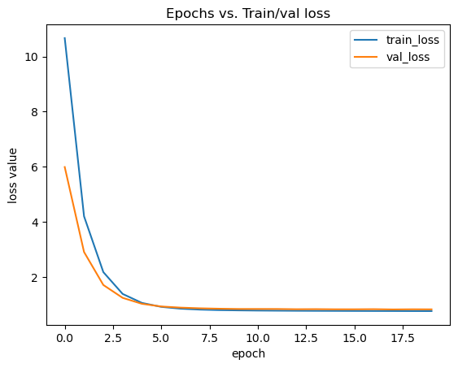

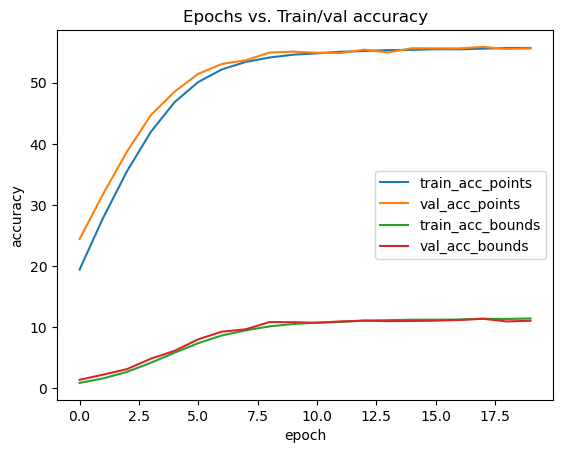

```python
# Creating the model object
model1 = LinearModel(28*28, 4)
model1 = model1.to(device)

# Initialize loss function, optimizer and parameters
loss_fn = torch.nn.MSELoss()
learning_rate = 0.01
optimizer = torch.optim.SGD(model1.parameters(), lr=learning_rate)
n_epochs = 20


# Training the model
train_losses, val_losses, train_acc_points, train_acc_bounds, val_acc_points, val_acc_bounds= train(model1, train_loader, valid_loader, optimizer, loss_fn, n_epochs)
# Plotting the results of the model
plot(n_epochs, train_losses, val_losses, train_acc_points, train_acc_bounds, val_acc_points, val_acc_bounds)


# Evaluating the model

num_correct = 0
num_good = 0

for digit, label in tqdm(test_loader):

    output = model1(torch.cat([digit], dim=1).view(-1, 1 * 28 * 28)).round()
    num_correct += (output == label).sum()
    num_good += torch.all((output == label), dim=1).sum()

print(f"Correct points overall: {num_correct}")
print(f"Accuracy points: {num_correct / (4*len(test_set))}")
print(f"Accuracy full correct: {num_good / len(test_set)}")
```

### Creating and training the second model

For this one the change is that we use the CrossEntropyLoss function knowing that is not the best one. And later in the metrics we can see how it completely fails to achieve a good or even stable accuracy.

```
Train metrics      --> loss: 252.5655, point acc: 0.6181, box acc: 0.0000
Validation metrics --> loss: 248.3078, point acc: 1.0333, box acc: 0.0000
```

```
Train metrics      --> loss: 246.0337, point acc: 0.5880, box acc: 0.0000
Validation metrics --> loss: 423.9636, point acc: 2.2583, box acc: 0.0000
```

```
Train metrics      --> loss: 252.2723, point acc: 0.6653, box acc: 0.0000
Validation metrics --> loss: 265.9041, point acc: 4.1333, box acc: 0.0000
```

```
Train metrics      --> loss: 251.7792, point acc: 0.6111, box acc: 0.0000
Validation metrics --> loss: 316.8486, point acc: 0.0125, box acc: 0.0000
```

```
Train metrics      --> loss: 250.1949, point acc: 0.5963, box acc: 0.0000
Validation metrics --> loss: 121.6464, point acc: 0.3250, box acc: 0.0000
```

```
Train metrics      --> loss: 252.8410, point acc: 0.7019, box acc: 0.0000
Validation metrics --> loss: 101.2306, point acc: 0.0000, box acc: 0.0000
```

```
Train metrics      --> loss: 252.0657, point acc: 0.6491, box acc: 0.0000
Validation metrics --> loss: 347.3991, point acc: 0.1875, box acc: 0.0000
```

```
Train metrics      --> loss: 248.5949, point acc: 0.6194, box acc: 0.0000
Validation metrics --> loss: 190.2446, point acc: 0.0042, box acc: 0.0000
```

```
Train metrics      --> loss: 252.0664, point acc: 0.5546, box acc: 0.0000
Validation metrics --> loss: 412.6756, point acc: 0.0042, box acc: 0.0000
```

```
Train metrics      --> loss: 252.0726, point acc: 0.6606, box acc: 0.0000
Validation metrics --> loss: 193.1332, point acc: 0.0000, box acc: 0.0000
```

```
Train metrics      --> loss: 249.2719, point acc: 0.6167, box acc: 0.0000
Validation metrics --> loss: 159.2054, point acc: 0.0000, box acc: 0.0000
```

```
Train metrics      --> loss: 250.8253, point acc: 0.6060, box acc: 0.0000
Validation metrics --> loss: 176.8076, point acc: 0.0000, box acc: 0.0000
```

```
Train metrics      --> loss: 250.6654, point acc: 0.6185, box acc: 0.0000
Validation metrics --> loss: 294.3744, point acc: 0.7000, box acc: 0.0000
```

```
Train metrics      --> loss: 250.4151, point acc: 0.6380, box acc: 0.0000
Validation metrics --> loss: 124.1621, point acc: 0.0000, box acc: 0.0000
```

```
Train metrics      --> loss: 252.3775, point acc: 0.6347, box acc: 0.0000
Validation metrics --> loss: 297.4080, point acc: 0.0000, box acc: 0.0000
```

```
Train metrics      --> loss: 252.1131, point acc: 0.6366, box acc: 0.0000
Validation metrics --> loss: 209.5661, point acc: 0.0875, box acc: 0.0000
```

```
Train metrics      --> loss: 251.5338, point acc: 0.5681, box acc: 0.0000
Validation metrics --> loss: 168.3210, point acc: 0.0000, box acc: 0.0000
```

```
Train metrics      --> loss: 252.8274, point acc: 0.6227, box acc: 0.0000
Validation metrics --> loss: 311.6739, point acc: 0.0125, box acc: 0.0000
```

```
Train metrics      --> loss: 251.0246, point acc: 0.6440, box acc: 0.0000
Validation metrics --> loss: 282.0314, point acc: 2.9292, box acc: 0.0000
```

```
Train metrics      --> loss: 249.7447, point acc: 0.6588, box acc: 0.0000
Validation metrics --> loss: 224.6768, point acc: 0.0042, box acc: 0.0000
```

```
Correct points overall: 1
Accuracy points: 2.499999936844688e-05
Accuracy full correct: 0.0
```

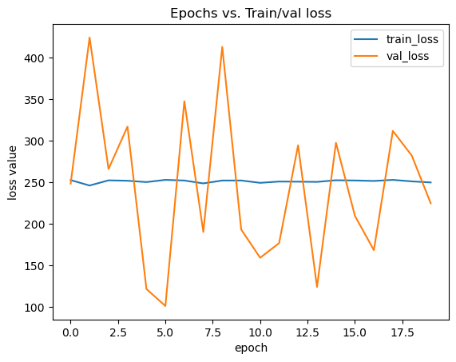

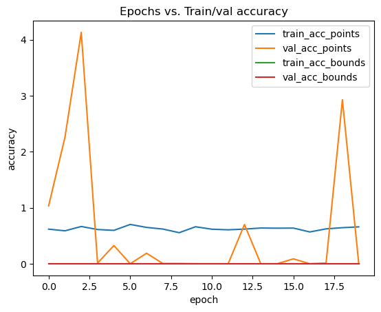

```python
# Creating the model object
model2 = LinearModel(28*28, 4)
model2 = model2.to(device)

# Initialize loss function, optimizer and parameters
loss_fn = torch.nn.CrossEntropyLoss()
learning_rate = 0.01
optimizer = torch.optim.SGD(model2.parameters(), lr=learning_rate)
n_epochs = 20


# Training the model
train_losses, val_losses, train_acc_points, train_acc_bounds, val_acc_points, val_acc_bounds= train(model2, train_loader, valid_loader, optimizer, loss_fn, n_epochs)
# Plotting the results of the model
plot(n_epochs, train_losses, val_losses, train_acc_points, train_acc_bounds, val_acc_points, val_acc_bounds)


# Evaluating the model

num_correct = 0
num_good = 0

for digit, label in tqdm(test_loader):

    output = model2(torch.cat([digit], dim=1).view(-1, 1 * 28 * 28)).round()
    num_correct += (output == label).sum()
    num_good += torch.all((output == label), dim=1).sum()

print(f"Correct points overall: {num_correct}")
print(f"Accuracy points: {num_correct / (4*len(test_set))}")
print(f"Accuracy full correct: {num_good / len(test_set)}")
```

### IoUs

Implement the intersection over union metric. For 2 rectangles $R_1$ and $R_2$ it is defined as: $$ IoU(R_1, R_2) = \frac{ S(R_1 \cap R_2)}{S(R_1 \cup R_2)}, $$ where $S$ stays for the area of the argument. What values of this metric are better?

#### The best values for the metric are the closser to 1 and the worst the closser to 0.

### Defining the intersection metric

For the implementation of the IoU metric I looked for help on some coding forums and found the formula for computing the intersection of two triangles in stack overflow: https://stackoverflow.com/questions/27152904/calculate-overlapped-area-between-two-rectangles

The implementation is of linear time complexity since it goes through a for loop, but could be improved with a vectorized implementation.

```python
def iou(pred: torch.Tensor, target: torch.Tensor) -> torch.Tensor:
    """
    Returns the average IoU metric between the two bounding boxes.

    :param pred: a tensor of shape [b, 4] of the predicted bounding boxes
    :param target: a tensor of shape [b, 4] of the ground truth bounding boxes
    :return: a tensor of shape [b,] of the IoU metric values per sample in the batch
    """

    ##### Write your code here #####

    l = pred.size(dim=0)

    res = torch.empty(l)

    for i in range(l):
        dx = min(pred[i][1], target[i][1]) - max(pred[i][0], target[i][0])
        dy = min(pred[i][3], target[i][3]) - max(pred[i][2], target[i][2])
        if (dx>=0) and (dy>=0):
            inter = dx*dy
        else:
            inter = 0

        pred_area   = (pred[i][1]-pred[i][0])*(pred[i][3]-pred[i][2])
        target_area = (target[i][1]-target[i][0])*(target[i][3]-target[i][2])

        res[i] = inter/(pred_area+target_area-inter)

    return res

    ################################
```

Report the train and validation IoUs of the linear model.

#### Results of using the IoUs metric on the train and validation dataset function

To make it easier to evaluate and being able to reuse it on the future, we make a function where the model is used to predict some values and with the correct label then it is calculated the mean IoU.

```python
def iou_calc(model, train_loader, val_loader):
    iou_values = []
    # for the training dataset
    with torch.no_grad():
        for digit, boundary in train_loader:
            # enabling gpu porcessing if available
            digit = digit.to(device)
            boundary = boundary.to(device)
            output = model(digit).round()
            iou_val = iou(output, boundary)
            iou_values += iou_val
        iou_mean = sum(iou_values)/len(iou_values)
        print("Mean IoU value for training set: {:.4f}".format(iou_mean))

    # for the validation dataset
    iou_values = []
    with torch.no_grad():
        for digit, boundary in val_loader:
            # enabling gpu porcessing if available
            digit = digit.to(device)
            boundary = boundary.to(device)
            output = model(digit).round()
            iou_val = iou(output, boundary)
            iou_values += iou_val
        iou_mean = sum(iou_values)/len(iou_values)
        print("Mean IoU value for validation set: {:.4f}".format(iou_mean))
```

#### Results for both linear models

```python
print("For model 1:")
model1.eval()
iou_calc(model1, train_loader, valid_loader)

print("\nFor model 2:")
model2.eval()
iou_calc(model2, train_loader, valid_loader)
```

```
For model 1:
Mean IoU value for training set: 0.8656
Mean IoU value for validation set: 0.8649

For model 2:
Mean IoU value for training set: 0.0000
Mean IoU value for validation set: 0.0000
```

#### Based on this metrics the best linear model would be the first one, we could conclude that the second one fails completely on the task. And even the first one has a little more than 50% accuracy in border lines overall, but a little more than 11% in the complete boundary accuracy.

### Task 3. Train an MLP (multi-layer perceptron).

Design and train a wider and deeper model. Consider using different activation functions, normalization layers and dropout. Plot all the training curves.

```python
##### Write your code here #####

class MLPModel1(nn.Module):

    def __init__(self, input_dim, hidden_dim):
        super(MLPModel1, self).__init__()
        self.layers = nn.Sequential(
            nn.Linear(input_dim, hidden_dim),
            nn.ReLU(),
            nn.Linear(hidden_dim, hidden_dim),
            nn.ReLU(),
            nn.Linear(hidden_dim, hidden_dim),
            nn.ReLU(),
            nn.Linear(hidden_dim, 4)
        )

    def forward(self, input):
        input = input.view(input.size(0), -1)
        return self.layers(input)

################################
```

Try different configurations of the model. Select the best model using the validation set. Justify your choice.

#### Model 1 version 1

For this we use the usual parameters to see how it works, from last task we know the MSELoss should work nice.

```
Train metrics      --> loss: 9.9929, point acc: 31.4861, box acc: 2.2611
Validation metrics --> loss: 1.4357, point acc: 35.9583, box acc: 0.8500
```

```
Train metrics      --> loss: 0.6491, point acc: 56.0051, box acc: 10.8222
Validation metrics --> loss: 0.7162, point acc: 53.4750, box acc: 7.3167
```

```
Train metrics      --> loss: 0.4494, point acc: 65.6889, box acc: 19.7370
Validation metrics --> loss: 0.3730, point acc: 72.5292, box acc: 28.4667
```

```
Train metrics      --> loss: 0.3386, point acc: 71.3014, box acc: 26.6407
Validation metrics --> loss: 0.3017, point acc: 76.8167, box acc: 35.4167
```

```
Train metrics      --> loss: 0.2860, point acc: 74.9384, box acc: 31.8037
Validation metrics --> loss: 0.2996, point acc: 75.7375, box acc: 31.6833
```

```
Train metrics      --> loss: 0.2535, point acc: 77.1866, box acc: 35.4463
Validation metrics --> loss: 0.3203, point acc: 72.6208, box acc: 29.8333
```

```
Train metrics      --> loss: 0.2290, point acc: 79.2236, box acc: 39.4481
Validation metrics --> loss: 0.2776, point acc: 77.2583, box acc: 32.6167
```

```
Train metrics      --> loss: 0.2153, point acc: 80.3546, box acc: 41.3481
Validation metrics --> loss: 0.2239, point acc: 82.1750, box acc: 45.8500
```

```
Train metrics      --> loss: 0.2031, point acc: 81.5296, box acc: 43.9963
Validation metrics --> loss: 0.3292, point acc: 74.7875, box acc: 30.2333
```

```
Train metrics      --> loss: 0.1951, point acc: 82.0968, box acc: 45.3981
Validation metrics --> loss: 0.2720, point acc: 76.9667, box acc: 32.6000
```

```
Train metrics      --> loss: 0.1874, point acc: 82.8796, box acc: 46.9852
Validation metrics --> loss: 0.2557, point acc: 78.0792, box acc: 34.0833
```

```
Train metrics      --> loss: 0.1824, point acc: 83.3042, box acc: 47.8444
Validation metrics --> loss: 0.2352, point acc: 79.8167, box acc: 40.0167
```

```
Train metrics      --> loss: 0.1770, point acc: 83.8213, box acc: 49.0352
Validation metrics --> loss: 0.1983, point acc: 83.7167, box acc: 49.6500
```

```
Train metrics      --> loss: 0.1721, point acc: 84.1745, box acc: 49.7130
Validation metrics --> loss: 0.1870, point acc: 84.8417, box acc: 52.4167
```

```
Train metrics      --> loss: 0.1683, point acc: 84.6394, box acc: 50.8722
Validation metrics --> loss: 0.1804, point acc: 85.6542, box acc: 53.8833
```

```
Train metrics      --> loss: 0.1651, point acc: 84.8514, box acc: 51.3944
Validation metrics --> loss: 0.1900, point acc: 84.5792, box acc: 51.7000
```

```
Train metrics      --> loss: 0.1609, point acc: 85.2255, box acc: 52.4000
Validation metrics --> loss: 0.2498, point acc: 79.7875, box acc: 35.8500
```

```
Train metrics      --> loss: 0.1573, point acc: 85.6398, box acc: 53.3963
Validation metrics --> loss: 0.1939, point acc: 84.5208, box acc: 50.8833
```

```
Train metrics      --> loss: 0.1532, point acc: 85.9255, box acc: 53.8852
Validation metrics --> loss: 0.2573, point acc: 79.5042, box acc: 37.8333
```

```
Train metrics      --> loss: 0.1509, point acc: 86.1139, box acc: 54.6074
Validation metrics --> loss: 0.1709, point acc: 86.0750, box acc: 54.7333
```

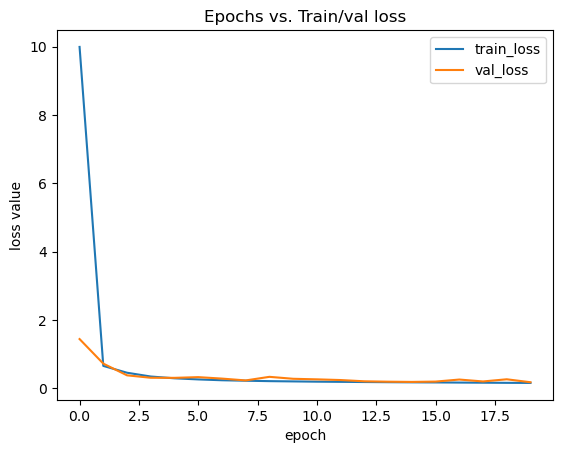

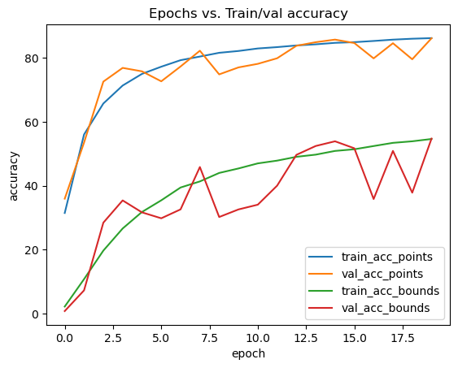

```python
##### Write your code here #####

# MODEL 1 version 1
MLModel11 = MLPModel1(28*28, 64)
MLModel11 = MLModel11.to(device)

# parameters
n_epochs = 20
learning_rate = 0.01
optimizer = torch.optim.SGD(MLModel11.parameters(), lr=learning_rate)
loss_fn = torch.nn.MSELoss()

# training and plotting
train_losses, val_losses, train_acc_points, train_acc_bounds, val_acc_points, val_acc_bounds = train(MLModel11, train_loader, valid_loader, optimizer, loss_fn, n_epochs)
plot(n_epochs, train_losses, val_losses, train_acc_points, train_acc_bounds, val_acc_points, val_acc_bounds)
```

#### Model 1 version 2

For this we use optimization Adam and the learning rate of 0.03.

```
Train metrics      --> loss: 6.3355, point acc: 27.8259, box acc: 1.4148
Validation metrics --> loss: 1.8061, point acc: 31.3542, box acc: 2.1500
```

```
Train metrics      --> loss: 1.7341, point acc: 31.3894, box acc: 2.1130
Validation metrics --> loss: 1.7555, point acc: 32.2917, box acc: 2.8833
```

```
Train metrics      --> loss: 1.7372, point acc: 31.3565, box acc: 2.0296
Validation metrics --> loss: 1.7451, point acc: 33.3333, box acc: 3.0333
```

```
Train metrics      --> loss: 1.7140, point acc: 31.3481, box acc: 2.1519
Validation metrics --> loss: 1.6572, point acc: 33.1833, box acc: 2.2333
```

```
Train metrics      --> loss: 1.6815, point acc: 31.9583, box acc: 2.3407
Validation metrics --> loss: 1.6529, point acc: 33.1167, box acc: 3.1000
```

```
Train metrics      --> loss: 1.6396, point acc: 32.1333, box acc: 2.4074
Validation metrics --> loss: 1.5766, point acc: 33.9250, box acc: 3.0500
```

```
Train metrics      --> loss: 1.6252, point acc: 32.5662, box acc: 2.5759
Validation metrics --> loss: 1.7204, point acc: 31.4542, box acc: 1.5667
```

```
Train metrics      --> loss: 1.6326, point acc: 32.3051, box acc: 2.3148
Validation metrics --> loss: 1.6021, point acc: 33.4083, box acc: 2.8833
```

```
Train metrics      --> loss: 1.5906, point acc: 32.7338, box acc: 2.4259
Validation metrics --> loss: 1.6476, point acc: 32.7708, box acc: 2.5333
```

```
Train metrics      --> loss: 1.5780, point acc: 32.6681, box acc: 2.4815
Validation metrics --> loss: 1.5553, point acc: 33.9292, box acc: 2.5500
```

```
Train metrics      --> loss: 1.5484, point acc: 32.9042, box acc: 2.5333
Validation metrics --> loss: 1.6166, point acc: 33.7333, box acc: 2.1333
```

```
Train metrics      --> loss: 1.5380, point acc: 33.0157, box acc: 2.4907
Validation metrics --> loss: 1.6575, point acc: 32.8375, box acc: 3.0167
```

```
Train metrics      --> loss: 1.5353, point acc: 33.1926, box acc: 2.8444
Validation metrics --> loss: 1.5317, point acc: 34.3458, box acc: 3.1667
```

```
Train metrics      --> loss: 1.5392, point acc: 33.2074, box acc: 2.6833
Validation metrics --> loss: 1.5192, point acc: 34.6750, box acc: 3.7167
```

```
Train metrics      --> loss: 1.5333, point acc: 33.4241, box acc: 2.9796
Validation metrics --> loss: 1.5528, point acc: 33.3750, box acc: 2.0500
```

```
Train metrics      --> loss: 1.5166, point acc: 33.3944, box acc: 2.7722
Validation metrics --> loss: 1.5350, point acc: 33.1917, box acc: 2.7833
```

```
Train metrics      --> loss: 1.5334, point acc: 33.2056, box acc: 2.7241
Validation metrics --> loss: 1.6799, point acc: 32.2500, box acc: 0.6833
```

```
Train metrics      --> loss: 1.5201, point acc: 33.3486, box acc: 2.8907
Validation metrics --> loss: 1.6206, point acc: 33.2000, box acc: 2.8500
```

```
Train metrics      --> loss: 1.5343, point acc: 33.1144, box acc: 2.7519
Validation metrics --> loss: 1.5555, point acc: 33.6208, box acc: 3.8500
```

```
Train metrics      --> loss: 1.5599, point acc: 32.8231, box acc: 2.6019
Validation metrics --> loss: 1.5297, point acc: 33.5542, box acc: 3.0667
```

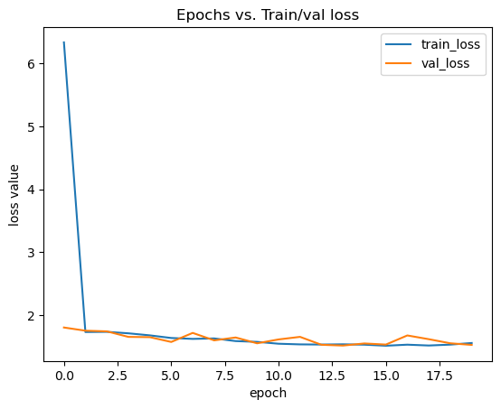

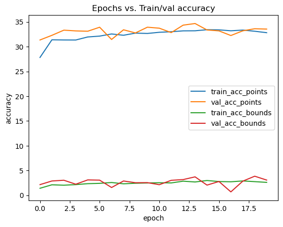

```python
# MODEL 1 version 2
MLModel12 = MLPModel1(28*28, 64)
MLModel12 = MLModel12.to(device)

# parameters
n_epochs = 20
learning_rate = 0.03
optimizer = torch.optim.Adam(MLModel12.parameters(), lr=learning_rate)
loss_fn = torch.nn.MSELoss()

# training and plotting
train_losses, val_losses, train_acc_points, train_acc_bounds, val_acc_points, val_acc_bounds = train(MLModel12, train_loader, valid_loader, optimizer, loss_fn, n_epochs)
plot(n_epochs, train_losses, val_losses, train_acc_points, train_acc_bounds, val_acc_points, val_acc_bounds)
```

#### Model 2

Experimenting with more different layers, different hidden dimension in each layer and different activation functions.

```python
class MLPModel2(nn.Module):

    #dimensions: 28*28, 16 x 16 x 32 x 32 x 64 x 64 x 32 x 32 x 16 x 16, 4
    def __init__(self, input_dim, hidden_dim):
        super(MLPModel2, self).__init__()
        self.layers = nn.Sequential(
            nn.Linear(input_dim, hidden_dim//4),
            nn.ReLU(),
            nn.Linear(hidden_dim//4, hidden_dim//2),
            nn.Sigmoid(),
            nn.Linear(hidden_dim//2, hidden_dim),
            nn.Sigmoid(),
            nn.Linear(hidden_dim, hidden_dim//2),
            nn.Sigmoid(),
            nn.Linear(hidden_dim//2, hidden_dim//4),
            nn.LeakyReLU(),
            nn.Linear(hidden_dim//4, 4),
        )

    def forward(self, input):
        input = input.view(input.size(0), -1)
        return self.layers(input)
```

#### Model 2 version 1

Learning rate of 0.01 and optimizer SGD

```
Train metrics      --> loss: 4.6166, point acc: 22.6810, box acc: 0.5241
Validation metrics --> loss: 3.5867, point acc: 22.9958, box acc: 1.8000
```

```
Train metrics      --> loss: 3.2225, point acc: 24.4227, box acc: 0.8074
Validation metrics --> loss: 3.2106, point acc: 24.2208, box acc: 1.0000
```

```
Train metrics      --> loss: 3.0479, point acc: 24.4699, box acc: 0.9167
Validation metrics --> loss: 3.0872, point acc: 24.7167, box acc: 0.8833
```

```
Train metrics      --> loss: 2.9955, point acc: 24.5741, box acc: 0.8833
Validation metrics --> loss: 3.2783, point acc: 23.2875, box acc: 0.1333
```

```
Train metrics      --> loss: 2.5800, point acc: 25.6736, box acc: 1.0352
Validation metrics --> loss: 1.9115, point acc: 30.4667, box acc: 2.1000
```

```
Train metrics      --> loss: 1.7195, point acc: 32.0588, box acc: 1.6667
Validation metrics --> loss: 1.6026, point acc: 32.3167, box acc: 1.0500
```

```
Train metrics      --> loss: 1.3999, point acc: 35.6681, box acc: 2.8981
Validation metrics --> loss: 1.3344, point acc: 37.6167, box acc: 3.8833
```

```
Train metrics      --> loss: 1.3284, point acc: 36.8097, box acc: 3.5056
Validation metrics --> loss: 1.2938, point acc: 38.9750, box acc: 4.7000
```

```
Train metrics      --> loss: 1.2320, point acc: 39.1579, box acc: 4.3741
Validation metrics --> loss: 1.2483, point acc: 40.8292, box acc: 2.9333
```

```
Train metrics      --> loss: 0.9011, point acc: 50.3949, box acc: 8.2741
Validation metrics --> loss: 0.9740, point acc: 47.4500, box acc: 7.2000
```

```
Train metrics      --> loss: 0.7914, point acc: 54.7227, box acc: 10.8370
Validation metrics --> loss: 0.9148, point acc: 49.7792, box acc: 8.2000
```

```
Train metrics      --> loss: 0.7660, point acc: 56.0495, box acc: 11.8241
Validation metrics --> loss: 0.9968, point acc: 51.8708, box acc: 7.4833
```

```
Train metrics      --> loss: 0.7382, point acc: 57.2912, box acc: 12.7537
Validation metrics --> loss: 0.9267, point acc: 47.9167, box acc: 6.8000
```

```
Train metrics      --> loss: 0.7025, point acc: 58.2736, box acc: 13.4315
Validation metrics --> loss: 0.6680, point acc: 61.3333, box acc: 15.5833
```

```
Train metrics      --> loss: 0.6038, point acc: 59.7472, box acc: 14.8056
Validation metrics --> loss: 0.7552, point acc: 51.5917, box acc: 7.6333
```

```
Train metrics      --> loss: 0.5500, point acc: 60.6556, box acc: 15.3074
Validation metrics --> loss: 0.5992, point acc: 60.2792, box acc: 13.9667
```

```
Train metrics      --> loss: 0.5254, point acc: 61.4560, box acc: 15.9722
Validation metrics --> loss: 0.6051, point acc: 60.0958, box acc: 13.2000
```

```
Train metrics      --> loss: 0.5061, point acc: 62.0931, box acc: 16.6648
Validation metrics --> loss: 0.6579, point acc: 58.5333, box acc: 9.8667
```

```
Train metrics      --> loss: 0.4813, point acc: 63.4167, box acc: 18.2278
Validation metrics --> loss: 0.5002, point acc: 64.1875, box acc: 19.1333
```

```
Train metrics      --> loss: 0.4702, point acc: 63.7338, box acc: 18.6926
Validation metrics --> loss: 0.4741, point acc: 68.0583, box acc: 22.9500
```

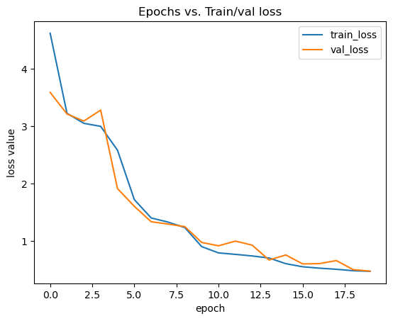

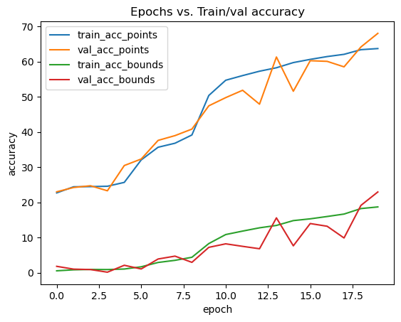

```python
# MODEL 2 version 1
MLModel21 = MLPModel2(28*28, 64)
MLModel21 = MLModel21.to(device)

# parameters
n_epochs = 20
learning_rate = 0.01
optimizer = torch.optim.SGD(MLModel21.parameters(), lr=learning_rate)
loss_fn = torch.nn.MSELoss()

# training and plotting
train_losses, val_losses, train_acc_points, train_acc_bounds, val_acc_points, val_acc_bounds = train(MLModel21, train_loader, valid_loader, optimizer, loss_fn, n_epochs)
plot(n_epochs, train_losses, val_losses, train_acc_points, train_acc_bounds, val_acc_points, val_acc_bounds)
```

#### Model 2 version 2

For this we use the learning rate of 0.03 and the optimizer Adam.

```
Train metrics      --> loss: 4.5666, point acc: 22.3935, box acc: 0.5667
Validation metrics --> loss: 3.7584, point acc: 23.4000, box acc: 1.7667
```

```
Train metrics      --> loss: 3.5397, point acc: 22.7514, box acc: 0.5315
Validation metrics --> loss: 3.5719, point acc: 23.1833, box acc: 0.0000
```

```
Train metrics      --> loss: 3.5525, point acc: 22.4630, box acc: 0.4685
Validation metrics --> loss: 3.5960, point acc: 22.9792, box acc: 1.8167
```

```
Train metrics      --> loss: 3.5002, point acc: 22.7176, box acc: 0.4574
Validation metrics --> loss: 3.5526, point acc: 22.6542, box acc: 1.4167
```

```
Train metrics      --> loss: 3.4875, point acc: 22.7769, box acc: 0.5648
Validation metrics --> loss: 3.5526, point acc: 22.6542, box acc: 1.4167
```

```
Train metrics      --> loss: 3.4799, point acc: 22.8208, box acc: 0.4963
Validation metrics --> loss: 3.5719, point acc: 23.1833, box acc: 0.0000
```

```
Train metrics      --> loss: 3.4673, point acc: 22.7986, box acc: 0.6167
Validation metrics --> loss: 3.5004, point acc: 23.1250, box acc: 0.0000
```

```
Train metrics      --> loss: 3.4555, point acc: 22.9329, box acc: 0.5685
Validation metrics --> loss: 3.5960, point acc: 22.9792, box acc: 1.8167
```

```
Train metrics      --> loss: 3.4559, point acc: 22.7870, box acc: 0.5611
Validation metrics --> loss: 3.4811, point acc: 22.5958, box acc: 0.5333
```

```
Train metrics      --> loss: 3.4534, point acc: 22.8620, box acc: 0.5037
Validation metrics --> loss: 3.4811, point acc: 22.5958, box acc: 0.5333
```

```
Train metrics      --> loss: 3.4480, point acc: 22.7181, box acc: 0.5204
Validation metrics --> loss: 3.4811, point acc: 22.5958, box acc: 0.5333
```

```
Train metrics      --> loss: 3.4455, point acc: 22.8324, box acc: 0.5500
Validation metrics --> loss: 3.5004, point acc: 23.1250, box acc: 0.0000
```

```
Train metrics      --> loss: 3.4477, point acc: 22.8597, box acc: 0.5111
Validation metrics --> loss: 3.5004, point acc: 23.1250, box acc: 0.0000
```

```
Train metrics      --> loss: 3.4473, point acc: 22.8019, box acc: 0.5278
Validation metrics --> loss: 3.5004, point acc: 23.1250, box acc: 0.0000
```

```
Train metrics      --> loss: 3.4391, point acc: 22.8421, box acc: 0.4796
Validation metrics --> loss: 3.5004, point acc: 23.1250, box acc: 0.0000
```

```
Train metrics      --> loss: 3.4374, point acc: 22.8102, box acc: 0.5111
Validation metrics --> loss: 3.4811, point acc: 22.5958, box acc: 0.5333
```

```
Train metrics      --> loss: 3.4283, point acc: 22.9019, box acc: 0.5500
Validation metrics --> loss: 3.4811, point acc: 22.5958, box acc: 0.5333
```

```
Train metrics      --> loss: 3.4138, point acc: 22.8903, box acc: 0.4611
Validation metrics --> loss: 3.4811, point acc: 22.5958, box acc: 0.5333
```

```
Train metrics      --> loss: 3.3935, point acc: 22.8796, box acc: 0.5204
Validation metrics --> loss: 3.4811, point acc: 22.5958, box acc: 0.5333
```

```
Train metrics      --> loss: 3.3996, point acc: 22.6755, box acc: 0.4407
Validation metrics --> loss: 3.4811, point acc: 22.5958, box acc: 0.5333
```

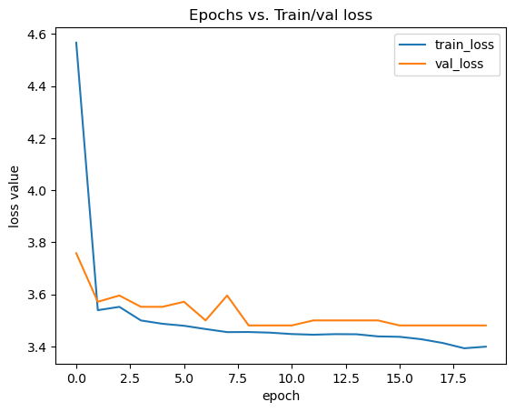

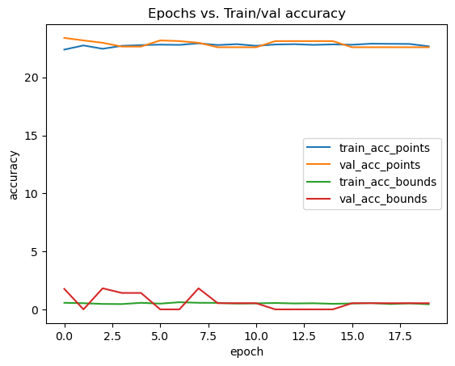

```python
# MODEL 2 version 2
MLModel22 = MLPModel2(28*28, 64)
MLModel22 = MLModel22.to(device)

# parameters
n_epochs = 20
learning_rate = 0.03
optimizer = torch.optim.Adam(MLModel22.parameters(), lr=learning_rate)
loss_fn = torch.nn.MSELoss()

# training and plotting
train_losses, val_losses, train_acc_points, train_acc_bounds, val_acc_points, val_acc_bounds = train(MLModel22, train_loader, valid_loader, optimizer, loss_fn, n_epochs)
plot(n_epochs, train_losses, val_losses, train_acc_points, train_acc_bounds, val_acc_points, val_acc_bounds)

################################
```

#### Using the iou metric as loss function for both models:

```python
def iou_loss(pred, boundary):
    return 1 - iou(pred, boundary).mean()
```

```
Train metrics      --> loss: 10.4915, point acc: 26.4875, box acc: 1.1426
Validation metrics --> loss: 1.7191, point acc: 34.2083, box acc: 1.6000
```

```
Train metrics      --> loss: 0.9046, point acc: 48.6352, box acc: 6.8130
Validation metrics --> loss: 0.6162, point acc: 60.4042, box acc: 14.1833
```

```
Train metrics      --> loss: 0.5059, point acc: 62.6218, box acc: 16.2796
Validation metrics --> loss: 0.4374, point acc: 67.1625, box acc: 20.2500
```

```
Train metrics      --> loss: 0.3500, point acc: 71.2458, box acc: 25.8704
Validation metrics --> loss: 0.5355, point acc: 62.9625, box acc: 12.3333
```

```
Train metrics      --> loss: 0.2971, point acc: 74.6227, box acc: 31.0019
Validation metrics --> loss: 0.4116, point acc: 71.0292, box acc: 25.2500
```

```
Train metrics      --> loss: 0.2676, point acc: 76.5255, box acc: 34.0870
Validation metrics --> loss: 0.6497, point acc: 53.2833, box acc: 11.9500
```

```
Train metrics      --> loss: 0.2504, point acc: 77.5148, box acc: 35.9037
Validation metrics --> loss: 0.3115, point acc: 73.6542, box acc: 30.0000
```

```
Train metrics      --> loss: 0.2339, point acc: 78.8852, box acc: 38.4963
Validation metrics --> loss: 0.2581, point acc: 78.6750, box acc: 37.0333
```

```
Train metrics      --> loss: 0.2206, point acc: 80.0634, box acc: 40.6778
Validation metrics --> loss: 0.2555, point acc: 78.9000, box acc: 37.9833
```

```
Train metrics      --> loss: 0.2099, point acc: 80.8232, box acc: 42.4148
Validation metrics --> loss: 0.2114, point acc: 82.8792, box acc: 46.7333
```

```
Train metrics      --> loss: 0.2013, point acc: 81.6000, box acc: 44.1556
Validation metrics --> loss: 0.2416, point acc: 80.8542, box acc: 42.3833
```

```
Train metrics      --> loss: 0.1943, point acc: 82.2449, box acc: 45.4333
Validation metrics --> loss: 0.2225, point acc: 81.6542, box acc: 44.2333
```

```
Train metrics      --> loss: 0.1879, point acc: 82.8269, box acc: 46.7963
Validation metrics --> loss: 0.1946, point acc: 84.4958, box acc: 50.8333
```

```
Train metrics      --> loss: 0.1833, point acc: 83.2690, box acc: 47.6630
Validation metrics --> loss: 0.2573, point acc: 77.8667, box acc: 34.7833
```

```
Train metrics      --> loss: 0.1785, point acc: 83.7370, box acc: 48.6556
Validation metrics --> loss: 0.1864, point acc: 84.6167, box acc: 51.5500
```

```
Train metrics      --> loss: 0.1735, point acc: 84.2486, box acc: 50.1019
Validation metrics --> loss: 0.1941, point acc: 84.4833, box acc: 51.6500
```

```
Train metrics      --> loss: 0.1702, point acc: 84.4977, box acc: 50.5185
Validation metrics --> loss: 0.1853, point acc: 85.2167, box acc: 52.7333
```

```
Train metrics      --> loss: 0.1678, point acc: 84.8005, box acc: 51.2944
Validation metrics --> loss: 0.1746, point acc: 85.9833, box acc: 55.3500
```

```
Train metrics      --> loss: 0.1634, point acc: 85.2009, box acc: 52.0907
Validation metrics --> loss: 0.1816, point acc: 85.3083, box acc: 53.4333
```

```
Train metrics      --> loss: 0.1617, point acc: 85.3028, box acc: 52.4981
Validation metrics --> loss: 0.1929, point acc: 84.0583, box acc: 50.8500
```

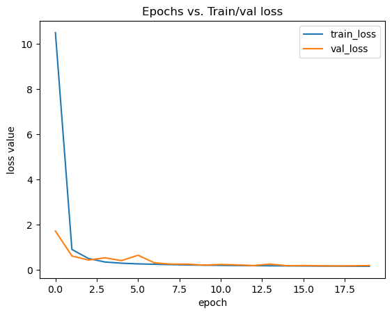

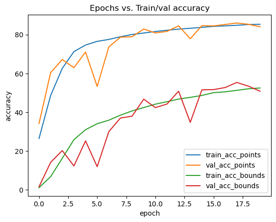

```python
# MODEL 1 version 3
MLModel13 = MLPModel1(28*28, 64)
MLModel13 = MLModel13.to(device)

# parameters
n_epochs = 20
learning_rate = 0.01
optimizer = torch.optim.SGD(MLModel13.parameters(), lr=learning_rate)
loss_fn = iou_loss

# training and plotting
train_losses, val_losses, train_acc_points, train_acc_bounds, val_acc_points, val_acc_bounds = train(MLModel13, train_loader, valid_loader, optimizer, loss_fn, n_epochs)
plot(n_epochs, train_losses, val_losses, train_acc_points, train_acc_bounds, val_acc_points, val_acc_bounds)
```

```
Train metrics      --> loss: 1.0000, point acc: 0.0074, box acc: 0.0000
Validation metrics --> loss: 1.0000, point acc: 0.0000, box acc: 0.0000
```

```
Train metrics      --> loss: 1.0000, point acc: 0.0074, box acc: 0.0000
Validation metrics --> loss: 1.0000, point acc: 0.0000, box acc: 0.0000
```

```
Train metrics      --> loss: 1.0000, point acc: 0.0074, box acc: 0.0000
Validation metrics --> loss: 1.0000, point acc: 0.0000, box acc: 0.0000
```

```
Train metrics      --> loss: 1.0000, point acc: 0.0074, box acc: 0.0000
Validation metrics --> loss: 1.0000, point acc: 0.0000, box acc: 0.0000
```

```
Train metrics      --> loss: 1.0000, point acc: 0.0074, box acc: 0.0000
Validation metrics --> loss: 1.0000, point acc: 0.0000, box acc: 0.0000
```

```
Train metrics      --> loss: 1.0000, point acc: 0.0074, box acc: 0.0000
Validation metrics --> loss: 1.0000, point acc: 0.0000, box acc: 0.0000
```

```
Train metrics      --> loss: 1.0000, point acc: 0.0074, box acc: 0.0000
Validation metrics --> loss: 1.0000, point acc: 0.0000, box acc: 0.0000
```

```
Train metrics      --> loss: 1.0000, point acc: 0.0074, box acc: 0.0000
Validation metrics --> loss: 1.0000, point acc: 0.0000, box acc: 0.0000
```

```
Train metrics      --> loss: 1.0000, point acc: 0.0074, box acc: 0.0000
Validation metrics --> loss: 1.0000, point acc: 0.0000, box acc: 0.0000
```

```
Train metrics      --> loss: 1.0000, point acc: 0.0074, box acc: 0.0000
Validation metrics --> loss: 1.0000, point acc: 0.0000, box acc: 0.0000
```

```
Train metrics      --> loss: 1.0000, point acc: 0.0074, box acc: 0.0000
Validation metrics --> loss: 1.0000, point acc: 0.0000, box acc: 0.0000
```

```
Train metrics      --> loss: 1.0000, point acc: 0.0074, box acc: 0.0000
Validation metrics --> loss: 1.0000, point acc: 0.0000, box acc: 0.0000
```

```
Train metrics      --> loss: 1.0000, point acc: 0.0074, box acc: 0.0000
Validation metrics --> loss: 1.0000, point acc: 0.0000, box acc: 0.0000
```

```
Train metrics      --> loss: 1.0000, point acc: 0.0074, box acc: 0.0000
Validation metrics --> loss: 1.0000, point acc: 0.0000, box acc: 0.0000
```

```
Train metrics      --> loss: 1.0000, point acc: 0.0074, box acc: 0.0000
Validation metrics --> loss: 1.0000, point acc: 0.0000, box acc: 0.0000
```

```
Train metrics      --> loss: 1.0000, point acc: 0.0074, box acc: 0.0000
Validation metrics --> loss: 1.0000, point acc: 0.0000, box acc: 0.0000
```

```
Train metrics      --> loss: 1.0000, point acc: 0.0074, box acc: 0.0000
Validation metrics --> loss: 1.0000, point acc: 0.0000, box acc: 0.0000
```

```
Train metrics      --> loss: 1.0000, point acc: 0.0074, box acc: 0.0000
Validation metrics --> loss: 1.0000, point acc: 0.0000, box acc: 0.0000
```

```
Train metrics      --> loss: 1.0000, point acc: 0.0074, box acc: 0.0000
Validation metrics --> loss: 1.0000, point acc: 0.0000, box acc: 0.0000
```

```
Train metrics      --> loss: 1.0000, point acc: 0.0074, box acc: 0.0000
Validation metrics --> loss: 1.0000, point acc: 0.0000, box acc: 0.0000
```

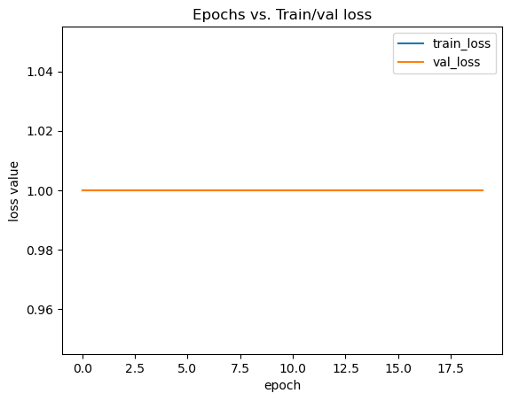

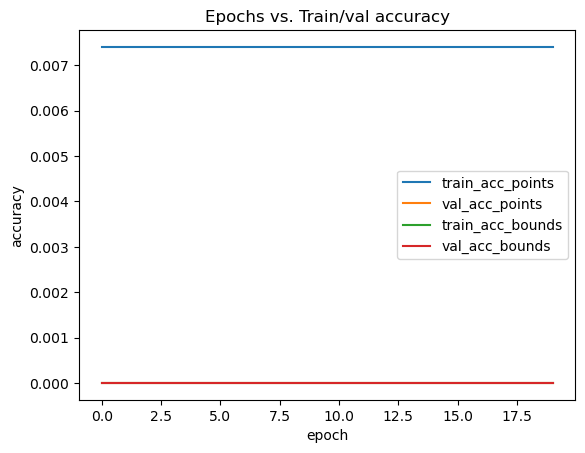

```python
# MODEL 2 version 3
MLModel23 = MLPModel2(28*28, 64)
MLModel23 = MLModel23.to(device)

# parameters
n_epochs = 20
learning_rate = 0.01
optimizer = torch.optim.SGD(MLModel23.parameters(), lr=learning_rate)
loss_fn = iou_loss

# training and plotting
train_losses, val_losses, train_acc_points, train_acc_bounds, val_acc_points, val_acc_bounds = train(MLModel23, train_loader, valid_loader, optimizer, loss_fn, n_epochs)
plot(n_epochs, train_losses, val_losses, train_acc_points, train_acc_bounds, val_acc_points, val_acc_bounds)
```

Evaluate your selected model on the test set and report the metric on the test set.

```
Train metrics      --> loss: 10.0221, point acc: 24.4755, box acc: 1.0056
Validation metrics --> loss: 1.7638, point acc: 32.9792, box acc: 1.7333
```

```
Train metrics      --> loss: 1.0965, point acc: 43.0917, box acc: 4.7500
Validation metrics --> loss: 0.8179, point acc: 53.7833, box acc: 9.8500
```

```
Train metrics      --> loss: 0.6811, point acc: 53.4398, box acc: 8.8167
Validation metrics --> loss: 0.7613, point acc: 52.6750, box acc: 7.0667
```

```
Train metrics      --> loss: 0.5573, point acc: 59.4824, box acc: 13.2519
Validation metrics --> loss: 0.6089, point acc: 61.6583, box acc: 14.4833
```

```
Train metrics      --> loss: 0.4990, point acc: 62.8329, box acc: 16.0074
Validation metrics --> loss: 0.8093, point acc: 51.8792, box acc: 6.6667
```

```
Train metrics      --> loss: 0.4643, point acc: 64.7699, box acc: 17.7093
Validation metrics --> loss: 0.5229, point acc: 65.3833, box acc: 18.4167
```

```
Train metrics      --> loss: 0.4265, point acc: 66.6153, box acc: 19.6241
Validation metrics --> loss: 0.4685, point acc: 68.4042, box acc: 21.6333
```

```
Train metrics      --> loss: 0.3960, point acc: 68.0843, box acc: 21.1204
Validation metrics --> loss: 0.4145, point acc: 71.2167, box acc: 25.8167
```

```
Train metrics      --> loss: 0.3705, point acc: 69.4546, box acc: 22.8796
Validation metrics --> loss: 0.4640, point acc: 68.1167, box acc: 19.6167
```

```
Train metrics      --> loss: 0.3464, point acc: 70.9347, box acc: 24.8944
Validation metrics --> loss: 0.4889, point acc: 66.1208, box acc: 17.8000
```

```
Train metrics      --> loss: 0.3261, point acc: 72.1014, box acc: 26.4185
Validation metrics --> loss: 0.4872, point acc: 67.6667, box acc: 16.0833
```

```
Train metrics      --> loss: 0.3151, point acc: 72.8426, box acc: 27.8333
Validation metrics --> loss: 0.4038, point acc: 71.4708, box acc: 23.7000
```

```
Train metrics      --> loss: 0.3015, point acc: 73.8315, box acc: 29.0370
Validation metrics --> loss: 0.3493, point acc: 74.7583, box acc: 30.6833
```

```
Train metrics      --> loss: 0.2970, point acc: 74.1940, box acc: 29.7778
Validation metrics --> loss: 0.3747, point acc: 73.7500, box acc: 29.1500
```

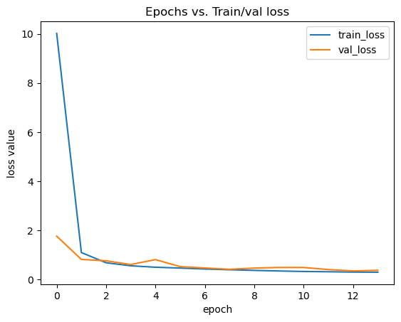

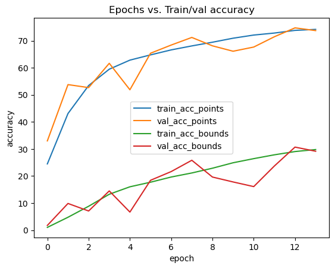

```python
##### Write your code here #####
# MODEL 1 version 1
MLModel13 = MLPModel1(28*28, 64)
MLModel13 = MLModel13.to(device)

# parameters
n_epochs = 14
learning_rate = 0.01
optimizer = torch.optim.SGD(MLModel13.parameters(), lr=learning_rate)
loss_fn = torch.nn.MSELoss()

# training and plotting
train_losses, val_losses, train_acc_points, train_acc_bounds, val_acc_points, val_acc_bounds = train(MLModel13, train_loader, valid_loader, optimizer, loss_fn, n_epochs)
plot(n_epochs, train_losses, val_losses, train_acc_points, train_acc_bounds, val_acc_points, val_acc_bounds)
```

```python
# Evaluation of model
num_correct = 0
num_good = 0

boundaries = []
digits = []
predictions = []
iou_values = []

MLModel11.eval()

for digit, boundary in tqdm(test_loader):

    with torch.no_grad():
        output = MLModel11(torch.cat([digit], dim=1).view(-1, 1 * 28 * 28))
        output = output.round()
    predictions.extend(output)
    digits.extend(digit)
    boundaries.extend(boundary)
    num_correct += (output == boundary).sum()
    num_good += torch.all((output == boundary), dim=1).sum()
    iou_val = iou(output, boundary)
    iou_values += iou_val
iou_mean = sum(iou_values)/len(iou_values)
print("Mean IoU value for test set: {:.4f}".format(iou_mean))

print(f"Correct points overall: {num_correct}")
print(f"Accuracy points: {num_correct / (4*len(test_set))}")
print(f"Accuracy full correct: {num_good / len(test_set)}")


################################
```

```
Mean IoU value for test set: 0.9569
Correct points overall: 34523
Accuracy points: 0.8630750179290771
Accuracy full correct: 0.5432999730110168
```

### Final remarks...

With more than 86% of all points correctly classified and adding to almost 55% of all the bounding boxes being correct, I think the model fulfills the task of creating suitable bounding boxes for the digits. Even the mean IoU value is very high, 0.9569, when the maximum value is 1.

Visualize some predictions of your model.

```python
##### Write your code here #####

def dataVisualization(img, bounds, pred):
    ### BOUNDARY
    # left
    x1_a = [bounds[0],bounds[0]]
    y1_a = [bounds[2],bounds[3]]
    # right
    x2_a = [bounds[1],bounds[1]]
    y2_a = [bounds[2],bounds[3]]
    # up
    x3_a = [bounds[0],bounds[1]]
    y3_a = [bounds[2],bounds[2]]
    # down
    x4_a = [bounds[0],bounds[1]]
    y4_a = [bounds[3],bounds[3]]
    ### PREDICTION
    # left
    x1_b = [pred[0],pred[0]]
    y1_b = [pred[2],pred[3]]
    # right
    x2_b = [pred[1],pred[1]]
    y2_b = [pred[2],pred[3]]
    # up
    x3_b = [pred[0],pred[1]]
    y3_b = [pred[2],pred[2]]
    # down
    x4_b = [pred[0],pred[1]]
    y4_b = [pred[3],pred[3]]

    pred = pred.unsqueeze(0)
    bounds = bounds.unsqueeze(0)
    metric = iou(pred, bounds)

    #plot boundary box
    plt.plot(x1_a,y1_a, 'r', linewidth=4.0)
    plt.plot(x2_a,y2_a, 'r', linewidth=4.0)
    plt.plot(x3_a,y3_a, 'r', linewidth=4.0)
    plt.plot(x4_a,y4_a, 'r', linewidth=4.0)
    #plot prediction box
    plt.plot(x1_b,y1_b, 'g', linewidth=2.0)
    plt.plot(x2_b,y2_b, 'g', linewidth=2.0)
    plt.plot(x3_b,y3_b, 'g', linewidth=2.0)
    plt.plot(x4_b,y4_b, 'g', linewidth=2.0)
    #plot title and image
    plt.suptitle(f"Boundary: {bounds.to(torch.long)}, Prediction: {pred.to(torch.long)}, IOU: {metric}")
    plt.imshow(img, cmap="gray")

################################
```

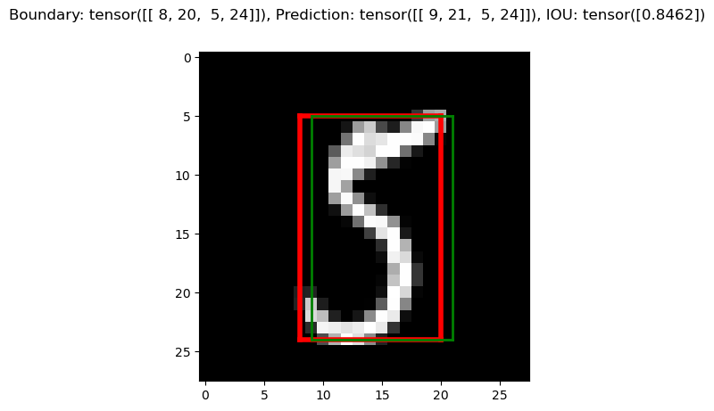

```python
num = random.randint(0, len(digits))
dataVisualization(digits[num][0], boundaries[num], predictions[num])
```

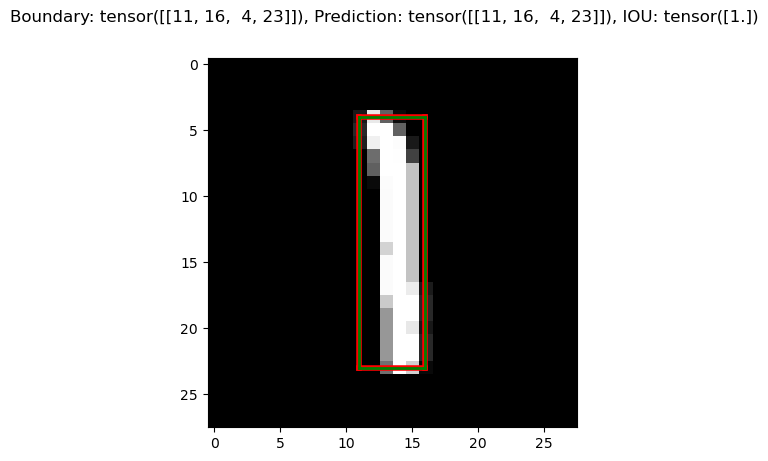

```python
num = random.randint(0, len(digits))
dataVisualization(digits[num][0], boundaries[num], predictions[num])
```

#### Even in some specific cases the prediction arguably seems to fit better than the original calculation. For example:

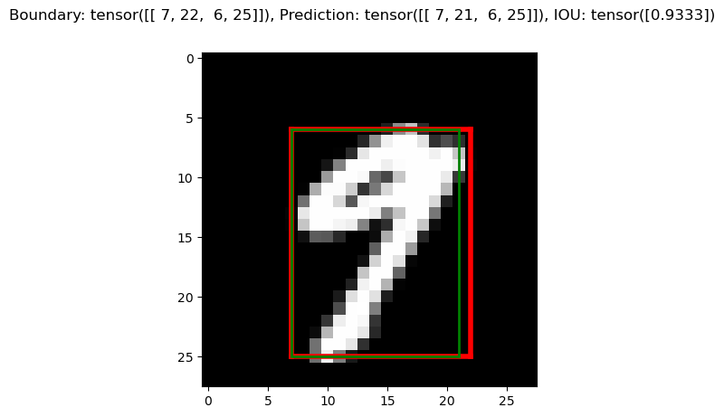

```python
num = 20
dataVisualization(digits[num][0], boundaries[num], predictions[num])
```